# TP3 AD: Dellouve & Gazzo

$$\textbf{Exercice 3}$$
$$\textit{I) Classification Ascendante Hiérarchique}$$
$\textit{Méthode étape par étape}$

On commence par initialiser nos données:

```r
library("FactoMineR")
library("factoextra")
A<-matrix(c(1,0,2,1,0,1,3,2,4,3,3,4,4,4),ncol=2, byrow=TRUE) # on défini X
X<-as.data.frame(A) # changement de format
colnames(X)<-c("var1", "var2") # on nomme les colonnes
rownames(X)<-c("w1", "w2", "w3","w4","w5","w6","w7") # on nomme les lignes
X # on affiche X
```

```
##    var1 var2
## w1    1    0
## w2    2    1
## w3    0    1
## w4    3    2
## w5    4    3
## w6    3    4
## w7    4    4
```

```r
# Distance euclidienne
dist <- dist(X, method = "euclidean")
dist
```

```
##          w1       w2       w3       w4       w5       w6
## w2 1.414214
## w3 1.414214 2.000000
## w4 2.828427 1.414214 3.162278
## w5 4.242641 2.828427 4.472136 1.414214
## w6 4.472136 3.162278 4.242641 2.000000 1.414214
## w7 5.000000 3.605551 5.000000 2.236068 1.000000 1.000000
```

```r
##La matrice des distances au carré
dist^2
```

```
##    w1 w2 w3 w4 w5 w6
## w2  2
## w3  2  4
## w4  8  2 10
## w5 18  8 20  2
## w6 20 10 18  4  2
## w7 25 13 25  5  1  1
```

```r
#La matrice des sauts de ward avec la distance au carré est:
ward1<-(dist^2)/8
ward1
```

```
##       w1    w2    w3    w4    w5    w6
## w2 0.250
## w3 0.250 0.500
## w4 1.000 0.250 1.250
## w5 2.250 1.000 2.500 0.250
## w6 2.500 1.250 2.250 0.500 0.250
## w7 3.125 1.625 3.125 0.625 0.125 0.125
```

On constate que les deux individus les plus proches sont $w_7$ et $w_5$ ou $w_7$ et $w_6$ (distance égale). On peut représenter plus “visuellement” ces matrices avec la fonction $\texttt{fviz_dist}$.

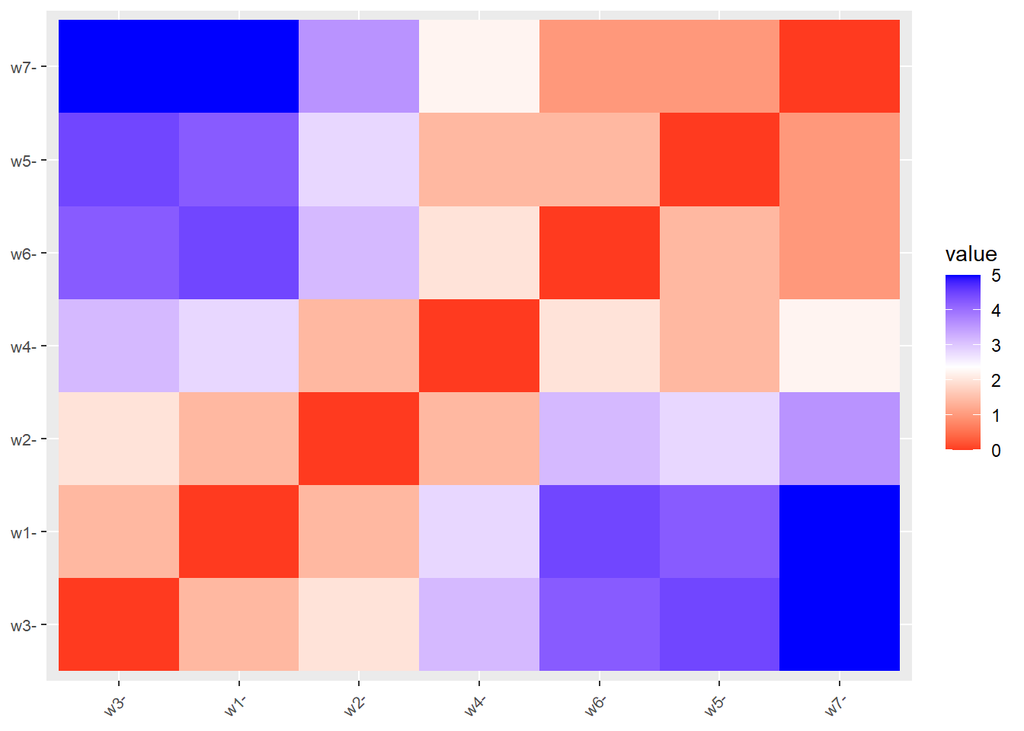

```r
fviz_dist(dist, lab_size = 8)
```

```r
##La plus petite perte d'inertie inter est entre w5 et W7
pertemin1<-min(ward1)
pertemin1
```

```
## [1] 0.125
```

Comme précédemment, on va calculer les distances entre $w_1$,$w_2$,$w_3$,$w_4$,$w_6$ et $g_{57}$, puis les distances au carré et enfin avec le saut de ward.

```r
A<-matrix(c(1,0,2,1,0,1,3,2,3,4,3.5,4),ncol=2, byrow=TRUE) # on défini X
X<-as.data.frame(A) # changement de format
colnames(X)<-c("var1", "var2") # on nomme les colonnes
rownames(X)<-c("w1", "w2", "w3","w4","w6","g57") # on nomme les lignes
X # on affiche X
```

```
##     var1 var2
## w1   1.0    0
## w2   2.0    1
## w3   0.0    1
## w4   3.0    2
## w6   3.0    4
## g57  3.5    4
```

```r
# Distance euclidienne
dist <- dist(X, method = "euclidean")
dist
```

```
##           w1       w2       w3       w4       w6
## w2  1.414214
## w3  1.414214 2.000000
## w4  2.828427 1.414214 3.162278
## w6  4.472136 3.162278 4.242641 2.000000
## g57 4.716991 3.354102 4.609772 2.061553 0.500000
```

```r
##La matrice des distances au carré
dist^2
```

```
##        w1    w2    w3    w4    w6
## w2   2.00
## w3   2.00  4.00
## w4   8.00  2.00 10.00
## w6  20.00 10.00 18.00  4.00
## g57 22.25 11.25 21.25  4.25  0.25
```

```r
#La matrice des sauts de ward avec la distance au carré est:
ward1<-(dist^2)/8
ward1
```

```
##          w1      w2      w3      w4      w6
## w2  0.25000
## w3  0.25000 0.50000
## w4  1.00000 0.25000 1.25000
## w6  2.50000 1.25000 2.25000 0.50000
## g57 2.78125 1.40625 2.65625 0.53125 0.03125
```

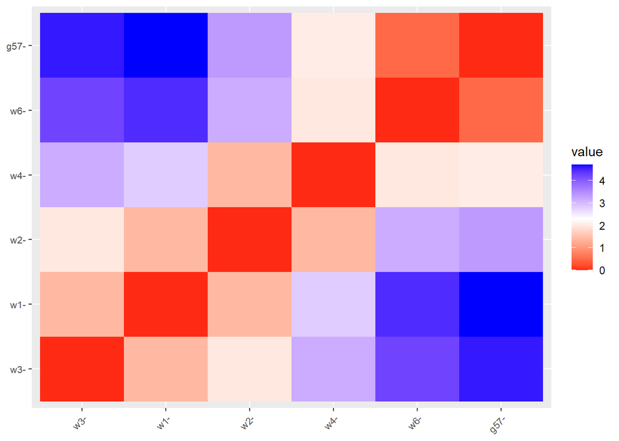

```r
fviz_dist(dist, lab_size = 8)
```

Après cette deuxième étape, on constate que ce sont les individus $w_6$ et $g_{57}$ qui sont les plus proches. Après les avoir regroupés, on obtient $g_{567}=(\frac{11}{3},\frac{11}{3})$, le centre du nouveau groupe.

```r
##La plus petite perte d'inertie inter est entre w6 et g57
pertemin1<-min(ward1)
pertemin1
```

```
## [1] 0.03125
```

A nouveau, on recalcule les distances entre $w_1$,$w_2$,$w_3$,$w_4$ et $g_{567}$. On continue ainsi jusqu’à ce que tous les $w_j, j \in 1 \dots 4$ soient dans une classe.

```r
A<-matrix(c(1,0,2,1,0,1,3,2,11./3,11./3),ncol=2, byrow=TRUE) # on défini X
X<-as.data.frame(A) # changement de format
colnames(X)<-c("var1", "var2") # on nomme les colonnes
rownames(X)<-c("w1", "w2", "w3","w4","g567") # on nomme les lignes
X # on affiche X
```

```
##          var1     var2
## w1   1.000000 0.000000
## w2   2.000000 1.000000
## w3   0.000000 1.000000
## w4   3.000000 2.000000
## g567 3.666667 3.666667
```

```r
# Distance euclidienne
dist <- dist(X, method = "euclidean")
dist
```

```
##            w1       w2       w3       w4
## w2   1.414214
## w3   1.414214 2.000000
## w4   2.828427 1.414214 3.162278
## g567 4.533824 3.144660 4.533824 1.795055
```

```r
##La matrice des distances au carré
dist^2
```

```
##             w1        w2        w3        w4
## w2    2.000000
## w3    2.000000  4.000000
## w4    8.000000  2.000000 10.000000
## g567 20.555556  9.888889 20.555556  3.222222
```

```r
#La matrice des sauts de ward avec la distance au carré est:
ward1<-(dist^2)/8
ward1
```

```
##             w1        w2        w3        w4
## w2   0.2500000
## w3   0.2500000 0.5000000
## w4   1.0000000 0.2500000 1.2500000
## g567 2.5694444 1.2361111 2.5694444 0.4027778
```

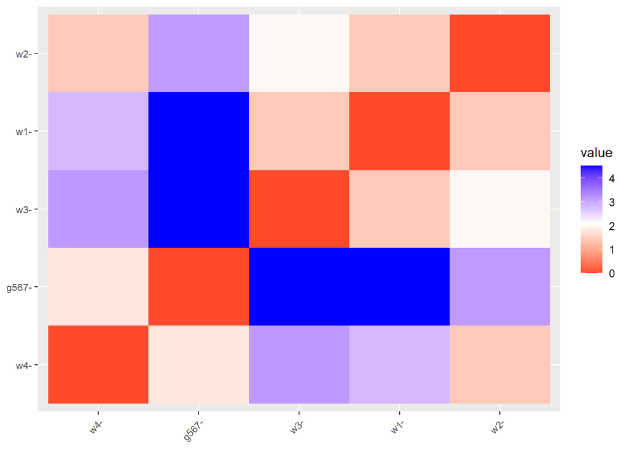

```r
##La plus petite perte d'inertie inter est entre w1 et w2
# on avait aussi w1 w3 et w4 w2

fviz_dist(dist, lab_size = 8)
```

Ici, on se retrouve dans un cadre un peu particulier: $(w_1,w_2)$, $(w_1,w_3)$ et $(w_2,w_4)$ sont les plus proches avec une distance égale. On a choisi de prendre $(w_1,w_2)$ et on a donc $g_{12}$ le centre de ce groupe tel que $g_{12}=(1.5,0.5)$.

```r
##La plus petite perte d'inertie inter est entre w1 et w2
pertemin1<-min(ward1)
pertemin1
```

```
## [1] 0.25
```

Ici, on recalcule les distances entre $g_{12}$,$w_3$,$w_4$ et $g_{567}$.

```r
A<-matrix(c(1.5,0.5,0,1,3,2,11./3,11./3),ncol=2, byrow=TRUE) # on défini X
X<-as.data.frame(A) # changement de format
colnames(X)<-c("var1", "var2") # on nomme les colonnes
rownames(X)<-c("g12", "w3","w4","g567") # on nomme les lignes
X # on affiche X
```

```
##          var1     var2
## g12  1.500000 0.500000
## w3   0.000000 1.000000
## w4   3.000000 2.000000
## g567 3.666667 3.666667
```

```r
# Distance euclidienne
dist <- dist(X, method = "euclidean")
dist
```

```
##           g12       w3       w4
## w3   1.581139
## w4   2.121320 3.162278
## g567 3.836955 4.533824 1.795055
```

```r
##La matrice des distances au carré
dist^2
```

```
##            g12        w3        w4
## w3    2.500000
## w4    4.500000 10.000000
## g567 14.722222 20.555556  3.222222
```

```r
#La matrice des sauts de ward avec la distance au carré est:
ward1<-(dist^2)/8
ward1
```

```
##            g12        w3        w4
## w3   0.3125000
## w4   0.5625000 1.2500000
## g567 1.8402778 2.5694444 0.4027778
```

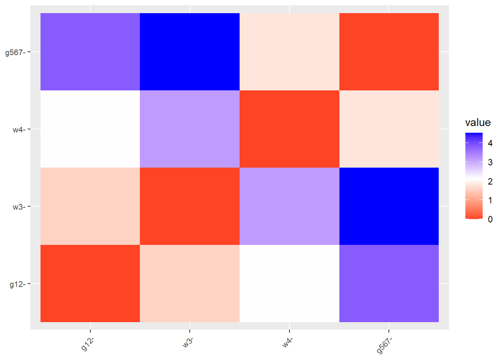

```r
fviz_dist(dist, lab_size = 8)
```

```r
##La plus petite perte d'inertie inter est entre g12 et w3
pertemin1<-min(ward1)
pertemin1
```

```
## [1] 0.3125
```

On regroupe $w_3$ et $g_{12}$. On obtient $g_{123}=(1,\frac{2}{3})$. On arrive à la dernière étape des calculs de distances.

```r
A<-matrix(c(1,2./3,3,2,11./3,11./3),ncol=2, byrow=TRUE) # on défini X
X<-as.data.frame(A) # changement de format
colnames(X)<-c("var1", "var2") # on nomme les colonnes
rownames(X)<-c("g123","w4","g567") # on nomme les lignes
X # on affiche X
```

```
##          var1      var2
## g123 1.000000 0.6666667
## w4   3.000000 2.0000000
## g567 3.666667 3.6666667
```

```r
# Distance euclidienne
dist <- dist(X, method = "euclidean")
dist
```

```
##          g123       w4
## w4   2.403701
## g567 4.013865 1.795055
```

```r
##La matrice des distances au carré
dist^2
```

```
##           g123        w4
## w4    5.777778
## g567 16.111111  3.222222
```

```r
#La matrice des sauts de ward avec la distance au carré est:
ward1<-(dist^2)/8
ward1
```

```
##           g123        w4
## w4   0.7222222
## g567 2.0138889 0.4027778
```

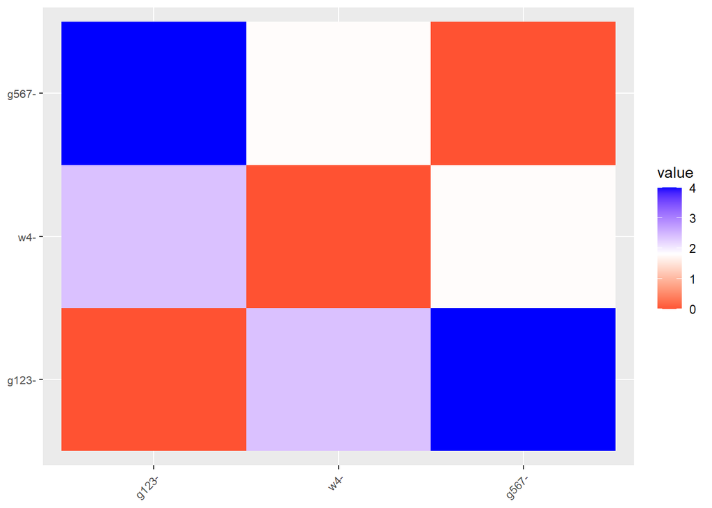

```r
fviz_dist(dist, lab_size = 8)
```

```r
##La plus petite perte d'inertie inter est entre g567 et w4
pertemin1<-min(ward1)
pertemin1
```

```
## [1] 0.4027778
```

On a donc deux groupes: l’un composé de $w_1$, $w_2$ et $w_3$ et l’autre composé de $w_4$, $w_5$, $w_6$ et $w_7$.

$\textit{Avec la fonction }\texttt{hclust}$

En fait, ces étapes que l’on a détaillé, peuvent se résumer et s’écrire sous $\texttt{R}$ grâce à la fonction $\texttt{hclust}$. Observons de plus près cette fonction.

```r
A<-matrix(c(1,0,2,1,0,1,3,2,4,3,3,4,4,4),ncol=2, byrow=TRUE) # on défini X
X<-as.data.frame(A) # changement de format
colnames(X)=c("var1", "var2") # on nomme les colonnes
rownames(X)=c("w1", "w2", "w3","w4","w5","w6","w7") # on nomme les lignes

# Distance euclidienne
## CAH sur des donnÃ©es brutes avec hclust ou eclust
# Distance euclidienne
dist <- dist(X, method = "euclidean")
# CAH avec Ward (option ward.D2 avec les distances au carrÃ© ou ward avec la distance)
hc <- hclust(dist, method = "ward.D2")
# Les regroupements pas Ã  pas
hc$merge
```

```
##      [,1] [,2]
## [1,]   -5   -7
## [2,]   -6    1
## [3,]   -1   -2
## [4,]   -3    3
## [5,]   -4    2
## [6,]    4    5
```

```r
# La hauteur des branches est la distance
hc$height
```

```
## [1] 1.000000 1.290994 1.414214 1.825742 2.198484 6.656540
```

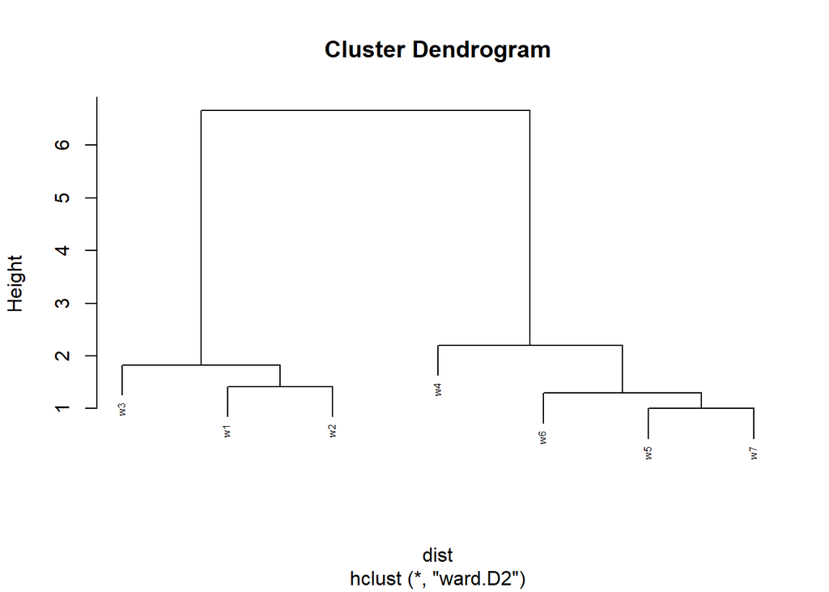

```r
# Arbre
plot(hc, cex = 0.5)
```

```r
cut<-cutree(hc,k=2)
print(sort(cut))
```

```
## w1 w2 w3 w4 w5 w6 w7
##  1  1  1  2  2  2  2
```

Comme observé précédemment avec la méthode étape par étape, la fonction $\texttt{hclust}$ a construit deux classes, regroupant d’un côté $w_1$, $w_2$ et $w_3$ et de l’autre w_4$, $w_5$, $w_6$ et $w_7$.

$\textit{Avec la fonction }\texttt{eclust}$

Il existe également une autre fonction sous $\texttt{R}$ nommée $\texttt{eclust}$.

```r
##CAH avec eclust de factoextra
hc2 <- eclust(X, k.max=3,"hclust")
hc2$merge
```

```
##      [,1] [,2]
## [1,]   -5   -7
## [2,]   -6    1
## [3,]   -1   -2
## [4,]   -3    3
## [5,]   -4    2
## [6,]    4    5
```

```r
hc2$height
```

```
## [1] 1.000000 1.290994 1.414214 1.825742 2.198484 6.656540
```

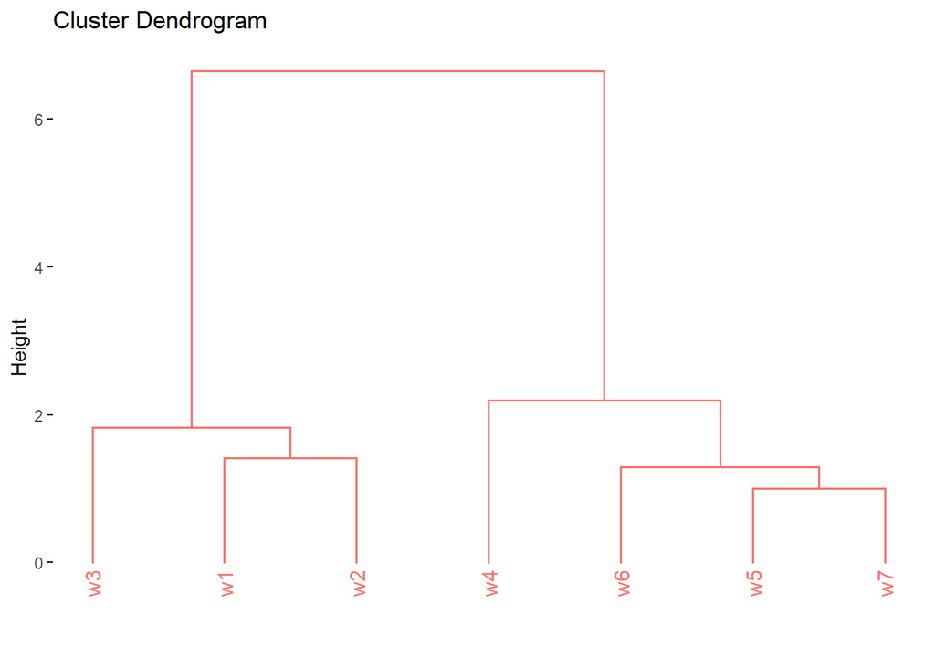

```r
# dendrogamme
fviz_dend(hc2)
```

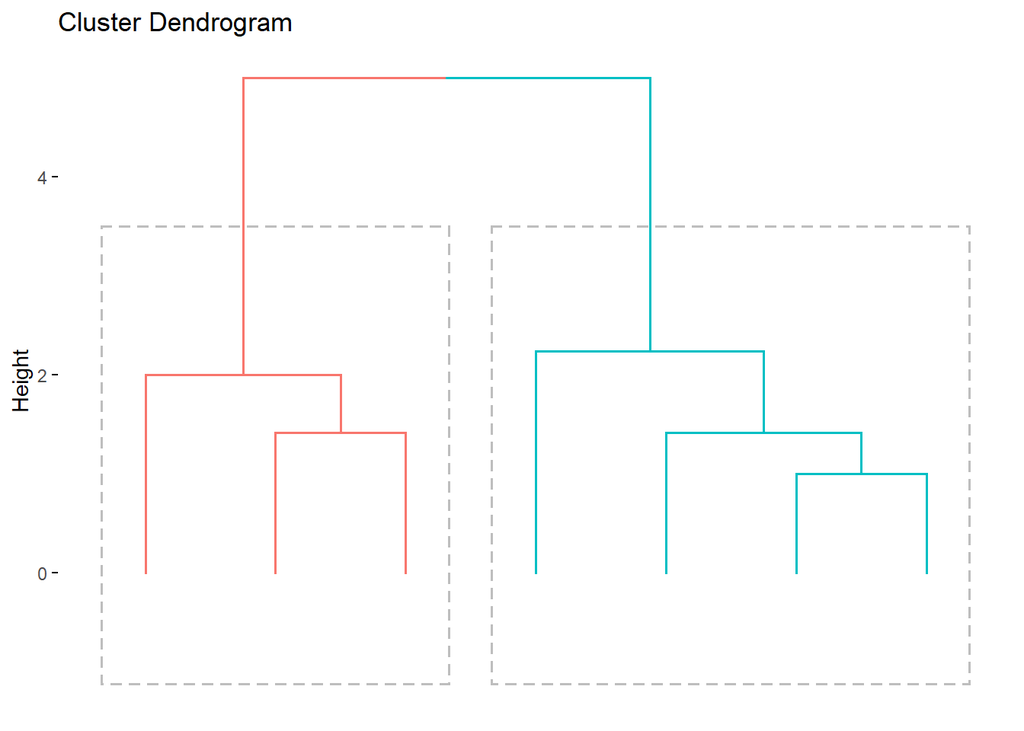

```r
## Couper le dendogramme pour avoir 2 classes
coupe <- hcut(X, k = 2, hc_method = "complete")
# Visualiser le dendrogramme avec les 2 classes
fviz_dend(coupe, show_labels = FALSE, rect = TRUE)
```

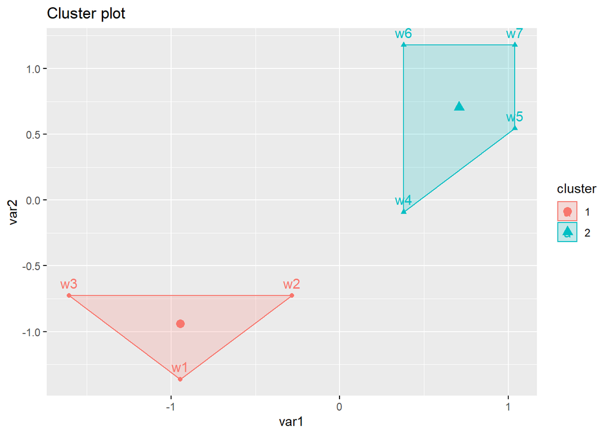

```r
# Visualiser les classes en fonction des variables
fviz_cluster(coupe, ellipse.type = "convex")
```

```
##   cluster size ave.sil.width
## 1       1    3          0.54
## 2       2    4          0.56
```

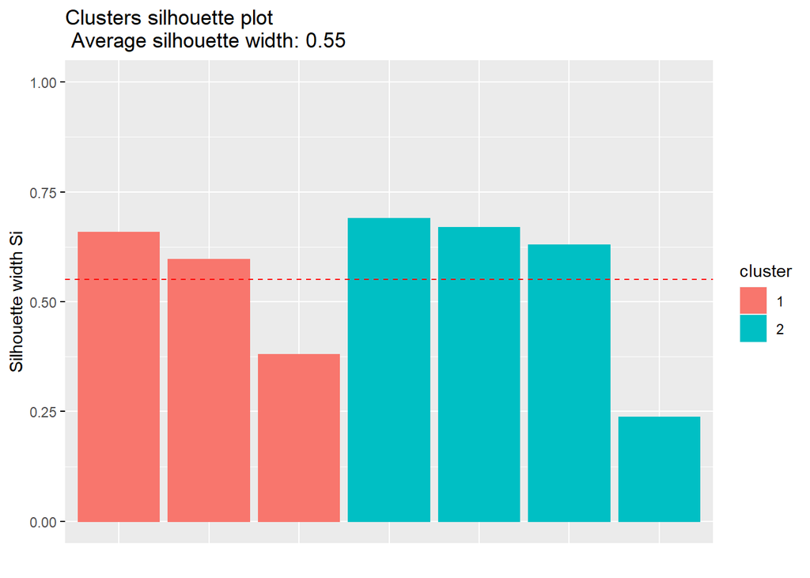

```r
# Visualize silhouhette information
fviz_silhouette(coupe)
```

La fonction $\texttt{eclust}$ nous donne la même conclusion qu’avec $\texttt{hclust}$. Cependant, $\texttt{eclust}$ nous apporte davantage de précisions, ce qui n’est pas négligeable. On pourra donc utiliser les deux indépendamment en fonction de notre préférence.

$\textbf{N.B.}$: On remarquera que $\texttt{eclust}$ nous donne la représentation graphique des clusters.

$$\textit{II) Les k-means en 2 classes}$$

Faisons la classiﬁcation avec $K = 2$ classes et de centres initiaux $w_5$ et $w_7$. On va procéder étape par étape. On prendra ici les distances, mais on aurait pu prendre les distances au carré ou le saut de Ward. Le but de cette première étape est de réunir les éléments les plus proches entre eux par rapport aux centres de départ (i.e. $w_5$ et $w_7$ dans notre cas).

```r
# Distance euclidienne

A<-matrix(c(1,0,2,1,0,1,3,2,4,3,3,4,4,4),ncol=2, byrow=TRUE) # on défini X
X<-as.data.frame(A) # changement de format
colnames(X)<-c("var1", "var2") # on nomme les colonnes
rownames(X)<-c("w1", "w2", "w3","w4","w5","w6","w7") # on nomme les lignes
X # on affiche X
```

```
##    var1 var2
## w1    1    0
## w2    2    1
## w3    0    1
## w4    3    2
## w5    4    3
## w6    3    4
## w7    4    4
```

```r
dist <- dist(X, method = "euclidean")
dist
```

```
##          w1       w2       w3       w4       w5       w6
## w2 1.414214
## w3 1.414214 2.000000
## w4 2.828427 1.414214 3.162278
## w5 4.242641 2.828427 4.472136 1.414214
## w6 4.472136 3.162278 4.242641 2.000000 1.414214
## w7 5.000000 3.605551 5.000000 2.236068 1.000000 1.000000
```

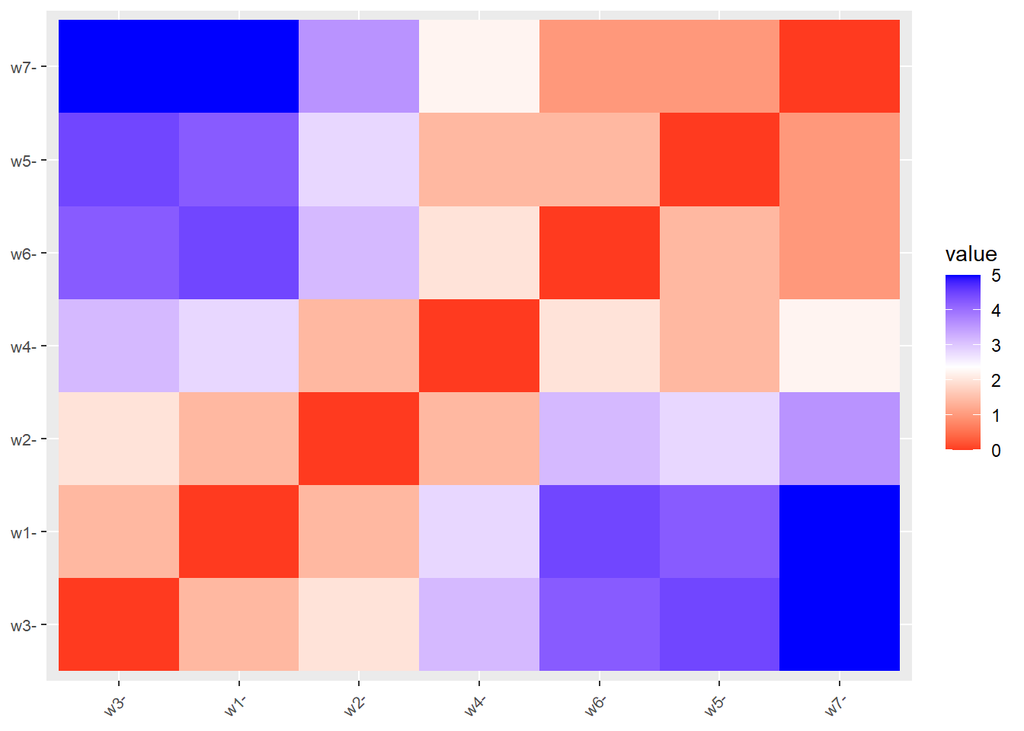

```r
fviz_dist(dist, lab_size = 8)
```

On constate après cette première étape que $g_1$ est composé de $w_1$, $w_2$, $w_3$, $w_4$ et $w_5$ car ces éléments (hors $w_5$ qui y est par initialisation) sont plus proches de $w_5$ que de $w_7$; et $g_2$ de $w_6$ et $w_7$ (car $w_6$ plus proche de $w_7$ que de $w_5$).

Continuons nos étapes, où le but sera maintenant de faire basculer, si besoin, des individus d’un groupe à l’autre car ils seront plus proches de l’autre groupe que de celui où ils sont actuellement. On continue jusqu’à ce que $g_1$ et $g_2$ restent les mêmes après une étape (i.e. qu’aucun individu ne change de groupe après une étape).

```r
A<-matrix(c(1,0,2,1,0,1,3,2,4,3,3,4,4,4,2,7./5,3.5,4),ncol=2, byrow=TRUE) # on défini X
X<-as.data.frame(A) # changement de format
colnames(X)<-c("var1", "var2") # on nomme les colonnes
rownames(X)<-c("w1", "w2", "w3","w4","w5","w6","w7","g1","g2") # on nomme les lignes
X # on affiche X
```

```
##    var1 var2
## w1  1.0  0.0
## w2  2.0  1.0
## w3  0.0  1.0
## w4  3.0  2.0
## w5  4.0  3.0
## w6  3.0  4.0
## w7  4.0  4.0
## g1  2.0  1.4
## g2  3.5  4.0
```

```r
# Distance euclidienne
dist <- dist(X, method = "euclidean")
dist
```

```
##          w1       w2       w3       w4       w5       w6       w7       g1
## w2 1.414214
## w3 1.414214 2.000000
## w4 2.828427 1.414214 3.162278
## w5 4.242641 2.828427 4.472136 1.414214
## w6 4.472136 3.162278 4.242641 2.000000 1.414214
## w7 5.000000 3.605551 5.000000 2.236068 1.000000 1.000000
## g1 1.720465 0.400000 2.039608 1.166190 2.561250 2.785678 3.280244
## g2 4.716991 3.354102 4.609772 2.061553 1.118034 0.500000 0.500000 3.001666
```

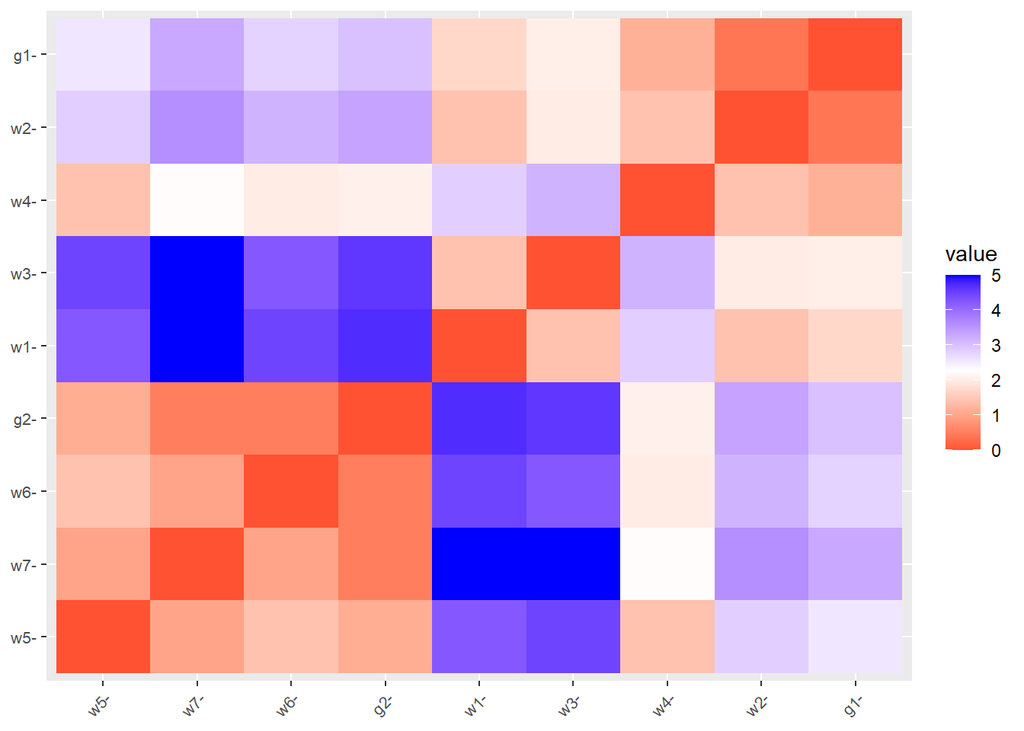

```r
fviz_dist(dist, lab_size = 8)
```

Ici, $w_5$ passe dans $g_2$ car il est plus proche de $g_2$ que de $g_1$, alors qu’il était dans $g_1$. Comme $g_1$ et $g_2$ ne sont plus les mêmes, on refait une étape.

```r
A<-matrix(c(1,0,2,1,0,1,3,2,4,3,3,4,4,4,6./4,1,11/3,11/3),ncol=2, byrow=TRUE) # on défini X
X<-as.data.frame(A) # changement de format
colnames(X)<-c("var1", "var2") # on nomme les colonnes
rownames(X)<-c("w1", "w2", "w3","w4","w5","w6","w7","g1","g2") # on nomme les lignes
X # on affiche X
```

```
##        var1     var2
## w1 1.000000 0.000000
## w2 2.000000 1.000000
## w3 0.000000 1.000000
## w4 3.000000 2.000000
## w5 4.000000 3.000000
## w6 3.000000 4.000000
## w7 4.000000 4.000000
## g1 1.500000 1.000000
## g2 3.666667 3.666667
```

```r
# Distance euclidienne
dist <- dist(X, method = "euclidean")
dist
```

```
##           w1        w2        w3        w4        w5        w6        w7
## w2 1.4142136
## w3 1.4142136 2.0000000
## w4 2.8284271 1.4142136 3.1622777
## w5 4.2426407 2.8284271 4.4721360 1.4142136
## w6 4.4721360 3.1622777 4.2426407 2.0000000 1.4142136
## w7 5.0000000 3.6055513 5.0000000 2.2360680 1.0000000 1.0000000
## g1 1.1180340 0.5000000 1.5000000 1.8027756 3.2015621 3.3541020 3.9051248
## g2 4.5338235 3.1446604 4.5338235 1.7950549 0.7453560 0.7453560 0.4714045
##           g1
## w2
## w3
## w4
## w5
## w6
## w7
## g1
## g2 3.4359214
```

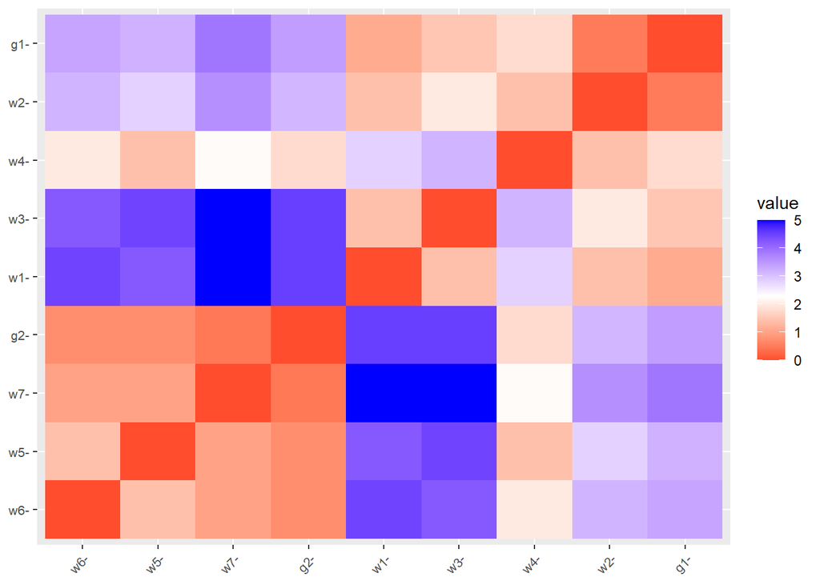

```r
fviz_dist(dist, lab_size = 8)
```

C’est au tour de $w_4$ de passer de $g_1$ à $g_2$ pour les mêmes raisons que $w_5$ avait fait ce chemin précédemment. On refait donc une étape.

```r
A<-matrix(c(1,0,2,1,0,1,3,2,4,3,3,4,4,4,1,2./3,14./4,13./4),ncol=2, byrow=TRUE) # on défini X
X<-as.data.frame(A) # changement de format
colnames(X)<-c("var1", "var2") # on nomme les colonnes
rownames(X)<-c("w1", "w2", "w3","w4","w5","w6","w7","g1","g2") # on nomme les lignes
X # on affiche X
```

```
##    var1      var2
## w1  1.0 0.0000000
## w2  2.0 1.0000000
## w3  0.0 1.0000000
## w4  3.0 2.0000000
## w5  4.0 3.0000000
## w6  3.0 4.0000000
## w7  4.0 4.0000000
## g1  1.0 0.6666667
## g2  3.5 3.2500000
```

```r
# Distance euclidienne
dist <- dist(X, method = "euclidean")
dist
```

```
##           w1        w2        w3        w4        w5        w6        w7
## w2 1.4142136
## w3 1.4142136 2.0000000
## w4 2.8284271 1.4142136 3.1622777
## w5 4.2426407 2.8284271 4.4721360 1.4142136
## w6 4.4721360 3.1622777 4.2426407 2.0000000 1.4142136
## w7 5.0000000 3.6055513 5.0000000 2.2360680 1.0000000 1.0000000
## g1 0.6666667 1.0540926 1.0540926 2.4037009 3.8005848 3.8873013 4.4845413
## g2 4.1003049 2.7041635 4.1608292 1.3462912 0.5590170 0.9013878 0.9013878
##           g1
## w2
## w3
## w4
## w5
## w6
## w7
## g1
## g2 3.5949424
```

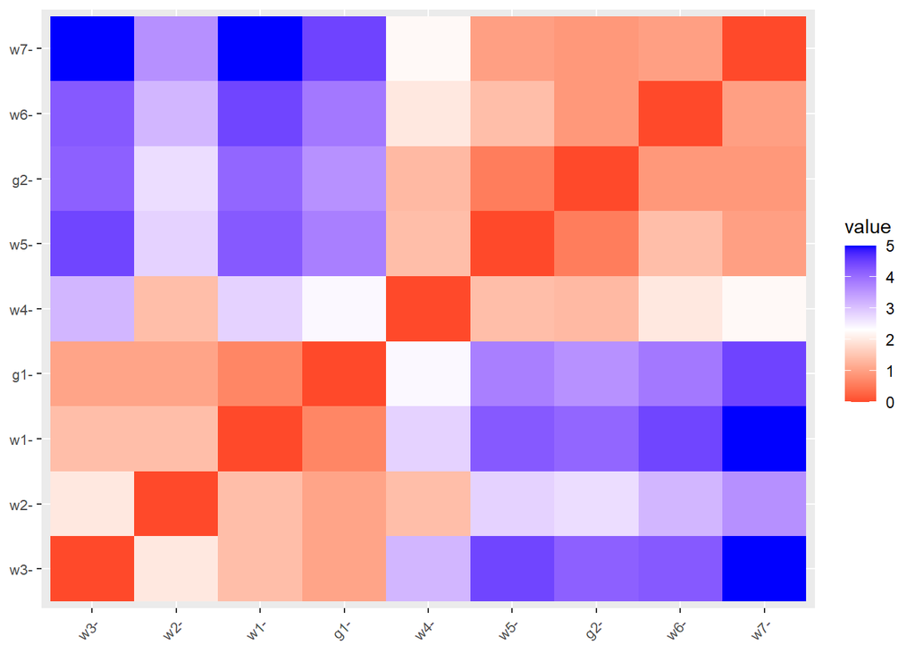

```r
fviz_dist(dist, lab_size = 8)
```

Cette fois, aucun individu ne change de classe: $g_1$ et $g_2$ restent identiques et on obtient nos groupes finaux. On constate que l’on retrouve le même résultat que pour CAH, c’est à dire un groupe composé de $w_1$, $w_2$ et $w_3$ et un autre composé de $w_4$, $w_5$, $w_6$ et $w_7$.

On passe maintenant aux graphiques via la fonction $\texttt{eclust}$:

```r
A<-matrix(c(1,0,2,1,0,1,3,2,4,3,3,4,4,4),ncol=2, byrow=TRUE) # on défini X
X<-as.data.frame(A) # changement de format
colnames(X)<-c("var1", "var2") # on nomme les colonnes
rownames(X)<-c("w1", "w2", "w3","w4","w5","w6","w7") # on nomme les lignes
X # on affiche X
```

```
##    var1 var2
## w1    1    0
## w2    2    1
## w3    0    1
## w4    3    2
## w5    4    3
## w6    3    4
## w7    4    4
```

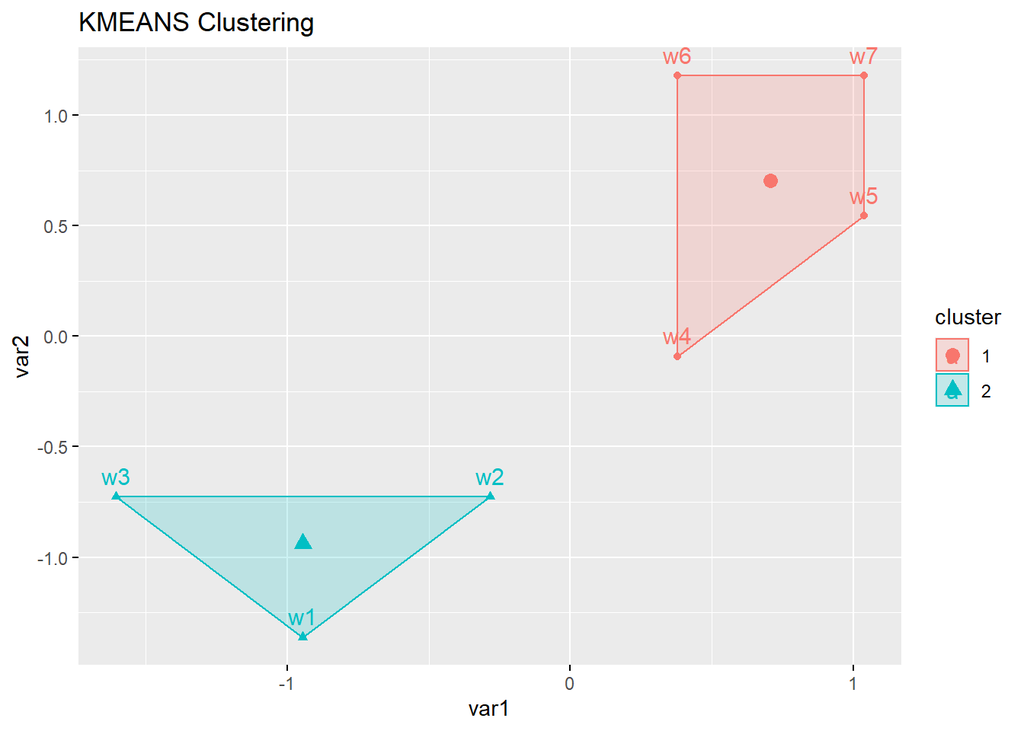

```r
##K-means
km <- eclust(X, "kmeans", k=2)
```

```r
km$cluster
```

```
## w1 w2 w3 w4 w5 w6 w7
##  2  2  2  1  1  1  1
```

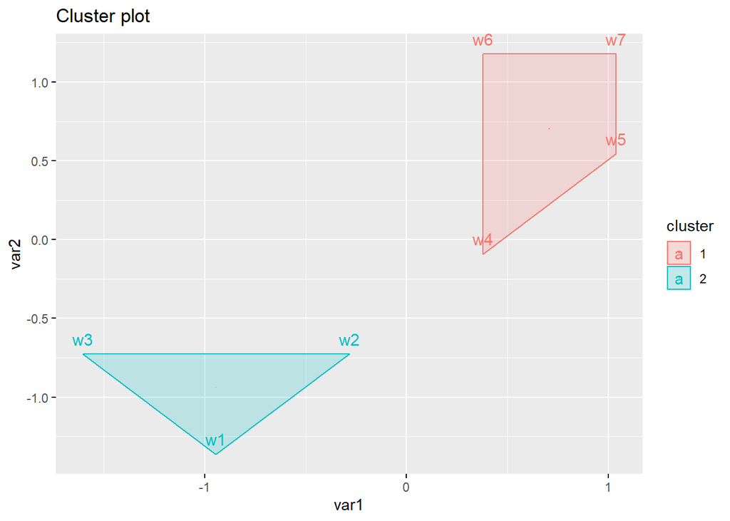

```r
# Visualisation
fviz_cluster(km, geom = "text")
```

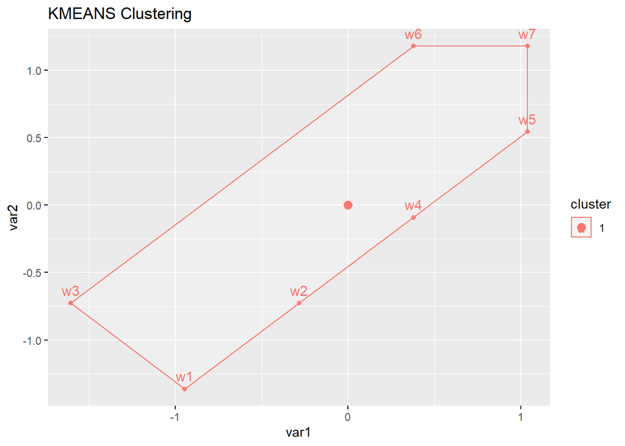

```r
## Choix de k
km <- eclust(X, "kmeans", nstart = 2, k.max=3)
```

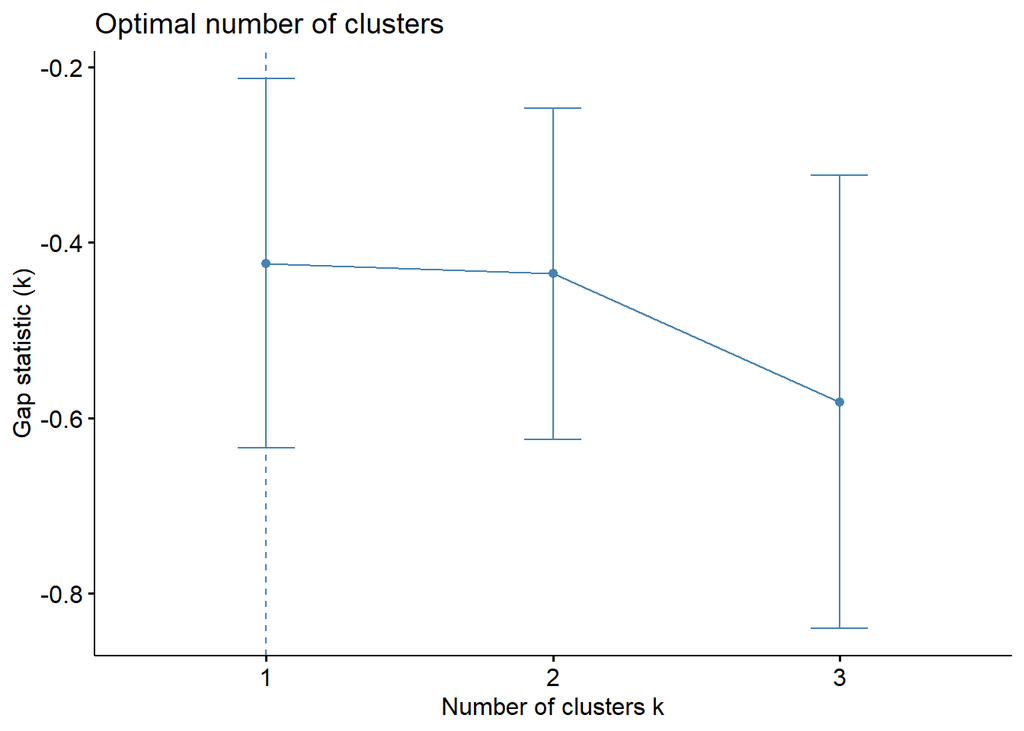

```r
##Gap
fviz_gap_stat(km$gap_stat)
```